# Лабораторна робота № 2

### Виконав: студент групи КН-25-1 Марусіченко А. О.

## Тема. Налагоджування та робота в середовищі Anaconda+Quarto. Мета: швидкий старт для роботи в середовищі Anaconda із застосуванням Jupyter Notebook, або Jupyter Notebook засобами мови програмування Python та видавничої системи Quarto.

Порядок виконання роботи

1. Завантажити і встановити збірку Python Anaconda.
2. Через інтерфейс командного рядка налагодити за допомогою conda віртуальне середовище з ім'ям _OpenCV. Етапи роботи підтвердити скріншотами. Використовується команда conda create -n Marusichenko_OpenCV python=3.11

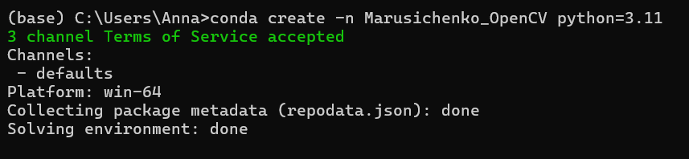

Рисунок 1 – Створення віртуального середовища

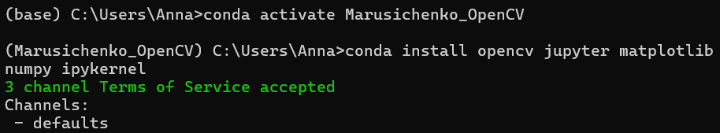

Рисунок 2 – Активація середовища

3. Проінсталювати у створене середовище пакети, необхідні для роботи з OpenCV.

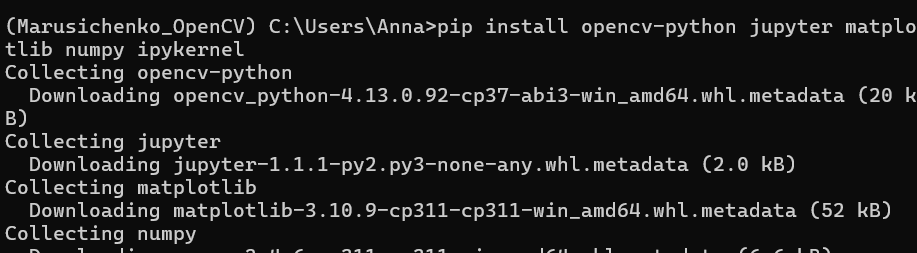

Рисунок 3 – Проінстальовані пакети та встановлення Jupyter Notebook

4. Створити Notebook-документ за допомогою Jupyter Notebook, або Jupyter Lab.

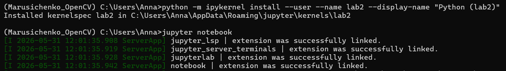

Рисунок 4 – Створення Notebook-документа

5. Скомпілювати звіт у форматі .html. Для цього необхідно завантажити термінал у робочому каталозі й у командному рядку запустити та таку команду: jupyter nbconvert lab_2_Marusichenko.ipynb --to html або, якщо наявна робота з налагодженим середовищем Quarto: quarto preview lab_2_Marusichenko.ipynb

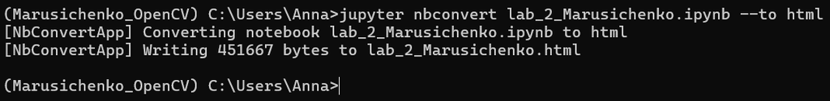

Рисунок 5 – Звіт у формат .html

## Контрольні питання

1. Платформа Anaconda є базовим стандартом курсу для зручного керування науковими пакетами.
2. Окреме середовище потрібне кожному проєкту для уникнення конфліктів між версіями пакетів.
3. Базове оточення є загальним і глобальним, а проєктне — чистим і налаштованим під конкретну роботу.
4. Текстовий файл використовують для точного фіксування та відновлення всіх бібліотек оточення.
5. Шлях до інтерпретатора визначають командою where python або кодом import sys; print(sys.executable).